# Variation Partitioning of Plant & Pollinator Communities and Interaction Networks

Cian White

30 October 2021

See this page for full tutorial https://cran.r-project.org/web/packages/adespatial/vignettes/tutorial.html#listw.explore

Once SWM is defined, it can be used to build Moran’s Eigenvector Maps (MEM; Dray, Legendre, and Peres-Neto (2006)) that are orthogonal vectors maximizing the spatial autocorrelation (measured by Moran’s coefficient). These spatial predictors can be used in multivariate statistical methods to provide spatially-explicit multiscale tools (Dray et al. 2012).

```r
#Packages
library(ade4)
library(adespatial)
library(adegraphics)
library(spdep)
library(maptools)
library(vegan)
library(betalink)
library(bipartite)
library(dplyr)
```

```r
#loading data
network <- read.csv("Cian_White_Interaction_Data_Full.csv")

#have to change a wrong value
network$Site_ID[network$X == 1949] <- 11
network$FlowerAbundancePerPlantSpecies[network$X == 1794] <- 10
network$FlowerVisitorSpecies[network$X == 729] <- "Bombus.lucorum(agg)"
network$FlowerVisitorSpecies[network$X == 829] <- "Bombus.lucorum(agg)"
network$FlowerVisitorSpecies[network$X == 839] <- "Bombus.lucorum(agg)"
network$FlowerVisitorSpecies[network$X == 905] <- "Bombus.lucorum(agg)"
network$FlowerVisitorSpecies[network$X == 922] <- "Bombus.lucorum(agg)"
network$FlowerVisitorSpecies[network$X == 925] <- "Bombus.lucorum(agg)"
network$FlowerVisitorSpecies[network$X == 934] <- "Bombus.lucorum(agg)"
network$FlowerVisitorSpecies[network$X == 1881] <- "Bombus.lucorum(agg)"
network$FlowerVisitorSpecies[network$X == 2298] <- "Bombus.lucorum(agg)"
network$FlowerVisitorSpecies <- gsub(" ", ",", network$FlowerVisitorSpecies)

network$FlowerVisitorSpecies <- as.factor(network$FlowerVisitorSpecies)
levels(network$FlowerVisitorSpecies)
```

```
 [1] "Andrena.cineraria"           "Andrena.haemorrhea"          "Andrena.lapponica"           "Andrena.scotica"
 [5] "Andrena.semilaevis"          "Andrena.wilkella"            "Apis.mellifera"              "Baccha.elongata"
 [9] "Bombus.hortorum"             "Bombus.lapidarius"           "Bombus.lucorum(agg)"         "Bombus.muscorum"
[13] "Bombus.pascorum"             "Bombus.pratorum"             "Bombus.ruderarius"           "Bombus.terrestris"
[17] "Cheiliosa.albitarsis"        "Cheiliosa.illustrata"        "Chrysotoxum.bicinctum"       "Coleoptera"
[21] "Common,Blue"                 "Dasysyrphus.albostriatus"    "Diptera"                     "Epistrophe.elegans"
[25] "Episyrphus.balteatus"        "Eristalis.arbustorum"        "Eristalis.intricaria"        "Eristalis.pertinax"
[29] "Eristalis.tenax"             "Eumerus.strigatus"           "Eupeodes.bucculatus(agg)"    "Eupeodes.corollae"
[33] "Eupeodes.latifasciatus"      "Eupeodes.luniger"            "Green.Veined.White"          "Halictus.rubundicus"
[37] "Halictus.tumulorum"          "Heliophilus.hybridus"        "Heliophilus.pendulus"        "Hoverfly"
[41] "Hylaeus.communis"            "Ivy,Blue"                    "Large.White"                 "Lassioglossum.albipes"
[45] "Lassioglossum.calceatum"     "Lassioglossum.nitifiusculum" "Lassioglossum.villosum"      "Lepidoptera"
[49] "Leucozona.lucorum"           "Meadow.Blue"                 "Meadow.brown"                "Megachile.centuncularis"
[53] "Megachile.versicolor"        "Melanogaster.hirtella"       "Melanostoma.mellinum"        "Melanostoma.scalare"
[57] "Meliscaeva.auricollis"       "Myathropa.florea"            "Neoascia.podagrica"          "Nomada.spp"
[61] "Orange.Tip"                  "Osmia.bicornis"              "PARASITOID,WASP"             "Parasyrphus.nigritarsus"
[65] "Platycheirus.albimanus"      "Platycheirus.clypaetus"      "Platycheirus.granditarsus"   "Platycheirus.manicatus"
[69] "Platycheirus.rosarum"        "Platycheirus.scutatus(agg)"  "Red.Admiral"                 "Rhingia.campestris"
[73] "Riponnesia.splendens"        "Scaeva.pyrastri"             "Scaeva.selenitica"           "Six.spotted.Burnet"
[77] "Small.Tortishell"            "Sphaerophoria(agg)"          "Syritta.pipiens"             "Syrphus.ribesii"
[81] "Syrphus.vitripennis"         "Tenthredo.sp"                "Vespula.spp"                 "Volucella.bombylans"
[85] "Volucella.pellucens"
```

```r
#creating dataframe with site ids and names for reference
network %>%
  select(Site_Name, Site_ID)  %>%
  arrange(Site_ID)  %>%
  unique() -> Names

#taking out networks from each site (aggregated by month)
netlist <- frame2webs(network, varnames = c("PlantSpecies",
                                            "FlowerVisitorSpecies",
                                            "Site_ID",
                                            "VisitationFrequency"),
                      type.out = "list", emptylist = TRUE)
```

```
NAs in VisitationFrequency converted to 0
```

```r
#creates I graph objects from the netlist dataframes
networks <- prepare_networks(netlist, directed = FALSE)

names <- name_networks(as.character(Names$Site_Name))
```

```
It is recommended to give names to your networks. I've done it for you.
```

```r
# plant community
network %>%
  select(Site_ID, PlantSpecies, FlowerAbundancePerPlantSpecies) %>%
  mutate(Group = 1) %>%
   frame2webs(varnames = c("Site_ID",
                                            "PlantSpecies",
                                            "Group",
                                            "FlowerAbundancePerPlantSpecies"),
                      type.out = "array",
                      emptylist = TRUE) -> plant_community
```

```
NAs in FlowerAbundancePerPlantSpecies converted to 0
```

```r
plant_community <- as.data.frame(plant_community)
colnames(plant_community) <- gsub(".1", "", colnames(plant_community))
#setting the apis at site three to correct abundance
plant_community$Hebe.agg[11] <- 0
plant_community$Oxalis.debilis[11] <- 0
plant_community$Vicia.sepium[18] <- 4
#write.csv(plant_community, "Plant_Community.csv")

# pollinator community
network %>%
  select(Site_ID, FlowerVisitorSpecies, VisitationFrequency) %>%
  mutate(Group = 1) %>%
   frame2webs(varnames = c("Site_ID",
                                            "FlowerVisitorSpecies",
                                            "Group",
                                            "VisitationFrequency"),
                      type.out = "array",
                      emptylist = TRUE) -> pollinator_community
```

```
NAs in VisitationFrequency converted to 0
```

```r
pollinator_community <- as.data.frame(pollinator_community)
colnames(pollinator_community) <- gsub(".1", "", colnames(pollinator_community))
#setting the apis at site three to correct abundance
pollinator_community$Apis.mellifera[3] <- 9
#setting the diptera at site three to correct abundance
pollinator_community$Diptera[7]  <- 47
#setting the meadow brown at site 8 to correct abundance
pollinator_community$Meadow.brown[8] <- 1
#setting the bombus luc agg at site 11 to correct abundance
pollinator_community$`Bombus.lucorum(agg)`[11] <- 18
#setting the bombus pratorum at site 11 to correct abundance
pollinator_community$Bombus.pratorum[11] <- 5
#setting the bombus pratorum at site 11 to correct abundance
pollinator_community$Bombus.pratorum[11] <- 5
```

Modifying Plant Names, adding in Plant Family and whether the species is Native or Introduced

```r
network$PlantSpecies <- as.factor(network$PlantSpecies)

levels(as.factor(network$PlantSpecies))

network$PlantSpecies <- as.character(network$PlantSpecies)

network$Introduced.[network$PlantSpecies == "Achillea.millefolium"] <- "N"
network$Plant_Family[network$PlantSpecies == "Achillea.millefolium"] <- "Asteraceae"

network$Introduced.[network$PlantSpecies == "Aconitum.napellus"] <- "I"
network$Plant_Family[network$PlantSpecies == "Aconitum.napellus"] <- "Ranunculaceae"

network$PlantSpecies[network$PlantSpecies == "Aegopodium.padagraria"] <- "Aegopodium.podagraria"
network$Introduced.[network$PlantSpecies == "Aegopodium.podagraria"] <- "I"
network$Plant_Family[network$PlantSpecies == "Aconitum.napellus"] <- "Apiaceae"

network$Introduced.[network$PlantSpecies == "Agapanthus.sp"] <- "I"
network$Plant_Family[network$PlantSpecies == "Aconitum.napellus"] <- "Amaryllidaceae"

network$Introduced.[network$PlantSpecies == "Ajuga.reptans"] <- "N"
network$Plant_Family[network$PlantSpecies == "Ajuga.reptans"] <- "Lamiaceae"

network$Introduced.[network$PlantSpecies == "Alcea.rosea"] <- "I"
network$Plant_Family[network$PlantSpecies == "Alcea.rosea"] <- "Malvaceae"

network$Introduced.[network$PlantSpecies == "Alliaria.petiolata"] <- "N"
network$Plant_Family[network$PlantSpecies == "Alliaria.petiolata"] <- "Brassicaceae"

network$Introduced.[network$PlantSpecies == "Allium.schoenoprasum"] <- "I"
network$Plant_Family[network$PlantSpecies == "Allium.schoenoprasum"] <- "Amaryllidaceae"

network$Introduced.[network$PlantSpecies == "Allium.triquetrum"] <- "I"
network$Plant_Family[network$PlantSpecies == "Allium.triquetrum"] <- "Amaryllidaceae"

network$Introduced.[network$PlantSpecies == "Alstroemeria.spp"] <- "I"
network$Plant_Family[network$PlantSpecies == "Alstroemeria.spp"] <- "Alstroemeriaceae"

network$Introduced.[network$PlantSpecies == "Anthriscus.sylvestris"] <- "N"
network$Plant_Family[network$PlantSpecies == "Anthriscus.sylvestris"] <- "Apiaceae"

network$Introduced.[network$PlantSpecies == "Anthyllis.vulneraria"] <- "N"
network$Plant_Family[network$PlantSpecies == "Anthyllis.vulneraria"] <- "Fabaceae"

network$PlantSpecies[network$PlantSpecies == "Antirrhinum.agg"] <- "Antirrhinum.majus"
network$Introduced.[network$PlantSpecies == "Antirrhinum.majus"] <- "N"
network$Plant_Family[network$PlantSpecies == "Antirrhinum.majus"] <- "Plantaginaceae"

network$Introduced.[network$PlantSpecies == "Astrantia.major"] <- "I"
network$Plant_Family[network$PlantSpecies == "Astrantia.major"] <- "Apiaceae"

network$Introduced.[network$PlantSpecies == "Aubrieta.deltoidea"] <- "I"
network$Plant_Family[network$PlantSpecies == "Aubrieta.deltoidea"] <- "Brassicaceae"

network$Introduced.[network$PlantSpecies == "Barbarea.vulgaris"] <- "N"
network$Plant_Family[network$PlantSpecies == "Barbarea.vulgaris"] <- "Brassicaceae"

network$Introduced.[network$PlantSpecies == "Begonia.semperflorens"] <- "I"
network$Plant_Family[network$PlantSpecies == "Begonia.semperflorens"] <- "Begoniaceae"

network$Introduced.[network$PlantSpecies == "Bellis.perennis"] <- "I"
network$Plant_Family[network$PlantSpecies == "Bellis.perennis"] <- "Asteraceae"

network$Introduced.[network$PlantSpecies == "Berberis.darwinii"] <- "I"
network$Plant_Family[network$PlantSpecies == "Berberis.darwinii"] <- "Berberidaceae"

network$Introduced.[network$PlantSpecies == "Berberis.sp"] <- "I"
network$Plant_Family[network$PlantSpecies == "Berberis.sp"] <- "Berberidaceae"

network$Introduced.[network$PlantSpecies == "Blue.Flower"] <- NA
network$Plant_Family[network$PlantSpecies == "Blue.Flower"] <- NA

network$Introduced.[network$PlantSpecies == "Brassica.rapa"] <- "I"
network$Plant_Family[network$PlantSpecies == "Brassica.rapa"] <- "Brassicaceae"

network$Introduced.[network$PlantSpecies == "Buddleja.davidii"] <- "I"
network$Plant_Family[network$PlantSpecies == "Buddleja.davidii"] <- "Scrophulariaceae"

network$Introduced.[network$PlantSpecies == "Buddleja.globosa"] <- "I"
network$Plant_Family[network$PlantSpecies == "Buddleja.globosa"] <- "Scrophulariaceae"

network$Introduced.[network$PlantSpecies == "Bunias.orientalis"] <- "I"
network$Plant_Family[network$PlantSpecies == "Bunias.orientalis"] <- "Brassicaceae"

network$Introduced.[network$PlantSpecies == "Buxus.sempervirens"] <- "I"
network$Plant_Family[network$PlantSpecies == "Buxus.sempervirens"] <- "Buxaceae"

network$Introduced.[network$PlantSpecies == "Calibrachoa.parviflora"] <- "I"
network$Plant_Family[network$PlantSpecies == "Calibrachoa.parviflora"] <- "Solanaceae"

network$PlantSpecies[network$PlantSpecies == "Calysteiga.sepium"] <- "Calystegia.sepium"
network$Introduced.[network$PlantSpecies == "Calystegia.sepium"] <- "N"
network$Plant_Family[network$PlantSpecies == "Calystegia.sepium"] <- "Solanaceae"

network$Introduced.[network$PlantSpecies == "Campanula.portenschlagia"] <- "I"
network$Plant_Family[network$PlantSpecies == "Campanula.portenschlagia"] <- "Campanulaceae"

network$Introduced.[network$PlantSpecies == "Campanula.rotundifolia"] <- "N"
network$Plant_Family[network$PlantSpecies == "Campanula.rotundifolia"] <- "Campanulaceae"

network$Introduced.[network$PlantSpecies == "Capsella.bursa-pastoris"] <- "N"
network$Plant_Family[network$PlantSpecies == "Capsella.bursa-pastoris"] <- "Brassicaceae"

network$PlantSpecies[network$PlantSpecies == "Cardamine.hirsutum"] <- "Cardamine.hirsuta"
network$Introduced.[network$PlantSpecies == "Cardamine.hirsuta"] <- "N"
network$Plant_Family[network$PlantSpecies == "Cardamine.hirsuta"] <- "Brassicaceae"

network$Introduced.[network$PlantSpecies == "Cardamine.pratensis"] <- "N"
network$Plant_Family[network$PlantSpecies == "Cardamine.pratensis"] <- "Brassicaceae"

network$Introduced.[network$PlantSpecies == "Ceanothus.agg"] <- "I"
network$Plant_Family[network$PlantSpecies == "Ceanothus.agg"] <- "Rhamnaceae"

network$Introduced.[network$PlantSpecies == "Centaurea.cyanus"] <- "I"
network$Plant_Family[network$PlantSpecies == "Centaurea.cyanus"] <- "Asteraceae"
```

```r
network$Introduced.[network$PlantSpecies == "Centaurea.nigra"] <- "N"
network$Plant_Family[network$PlantSpecies == "Centaurea.nigra"] <- "Asteraceae"

network$Introduced.[network$PlantSpecies == "Centranthus.ruber"] <- "I"
network$Plant_Family[network$PlantSpecies == "Centranthus.ruber"] <- "Caprifoliaceae"

network$Introduced.[network$PlantSpecies == "Cerastium.fontanum"] <- "N"
network$Plant_Family[network$PlantSpecies == "Cerastium.fontanum"] <- "Caryophyllaceae"

network$Introduced.[network$PlantSpecies == "Cerastium.tomentosum"] <- "I"
network$Plant_Family[network$PlantSpecies == "Cerastium.tomentosum"] <- "Caryophyllaceae"

network$PlantSpecies[network$PlantSpecies == "Chamerion.anguistifolium"] <- "Chamaenerion.angustifolium"
network$Introduced.[network$PlantSpecies == "Chamaenerion.angustifolium"] <- "I"
network$Plant_Family[network$PlantSpecies == "Chamaenerion.angustifolium"] <- "Onagraceae"

network$Introduced.[network$PlantSpecies == "Chenopodium.album"] <- "I"
network$Plant_Family[network$PlantSpecies == "Chenopodium.album"] <- "Amaranthaceae"

network$PlantSpecies[network$PlantSpecies == "Chrysanthemum.segtum"] <- "Chrysanthemum.segetum"
network$Introduced.[network$PlantSpecies == "Chrysanthemum.segetum"] <- "N"
network$Plant_Family[network$PlantSpecies == "Chrysanthemum.segetum"] <- "Asteraceae"

network$Introduced.[network$PlantSpecies == "Circaea.lutetiana"] <- "N"
network$Plant_Family[network$PlantSpecies == "Circaea.lutetiana"] <- "Onagraceae"

network$Introduced.[network$PlantSpecies == "Cirsium.arvense"] <- "N"
network$Plant_Family[network$PlantSpecies == "Cirsium.arvense"] <- "Asteraceae"

network$Introduced.[network$PlantSpecies == "Cirsium.palustre"] <- "N"
network$Plant_Family[network$PlantSpecies == "Cirsium.palustre"] <- "Asteraceae"

network$Introduced.[network$PlantSpecies == "Cirsium.vulgare"] <- "N"
network$Plant_Family[network$PlantSpecies == "Cirsium.vulgare"] <- "Asteraceae"

network$Introduced.[network$PlantSpecies == "Cistus.agg"] <- "I"
network$Plant_Family[network$PlantSpecies == "Cistus.agg"] <- "Cistaceae"

network$Introduced.[network$PlantSpecies == "Conopodium.majus"] <- "N"
network$Plant_Family[network$PlantSpecies == "Conopodium.majus"] <- "Apiaceae"

network$Introduced.[network$PlantSpecies == "Cornus.alba(Crimsam)"] <- "I"
network$Plant_Family[network$PlantSpecies == "Cornus.alba(Crimsam)"] <- "Cornaceae"

network$Introduced.[network$PlantSpecies == "Cotoneaster.franchetii"] <- "I"
network$Plant_Family[network$PlantSpecies == "Cotoneaster.franchetii"] <- "Rosaceae"

network$Introduced.[network$PlantSpecies == "Cotoneaster.frigidus"] <- "I"
network$Plant_Family[network$PlantSpecies == "Cotoneaster.frigidus"] <- "Rosaceae"

network$Introduced.[network$PlantSpecies == "Cotoneaster.hybridus.pendulus"] <- "I"
network$Plant_Family[network$PlantSpecies == "Cotoneaster.hybridus.pendulus"] <- "Rosaceae"

network$Introduced.[network$PlantSpecies == "Crataegus.monogyna"] <- "N"
network$Plant_Family[network$PlantSpecies == "Crataegus.monogyna"] <- "Rosaceae"

network$Introduced.[network$PlantSpecies == "Crepis.biennis"] <- "N"
network$Plant_Family[network$PlantSpecies == "Crepis.biennis"] <- "Asteraceae"

network$Introduced.[network$PlantSpecies == "Crepis.capillaris"] <- "N"
network$Plant_Family[network$PlantSpecies == "Crepis.capillaris"] <- "Asteraceae"

network$Introduced.[network$PlantSpecies == "Crocosmia.xcrocosmiiflora"] <- "I"
network$Plant_Family[network$PlantSpecies == "Crocosmia.xcrocosmiiflora"] <- "Iridaceae"

network$Introduced.[network$PlantSpecies == "Cytisus.scoparius"] <- "N"
network$Plant_Family[network$PlantSpecies == "Cytisus.scoparius"] <- "Fabaceae"

network$Introduced.[network$PlantSpecies == "Daucus.carota"] <- "N"
network$Plant_Family[network$PlantSpecies == "Daucus.carota"] <- "Apiaceae"

network$Introduced.[network$PlantSpecies == "Dianthus.caryophyllus"] <- "I"
network$Plant_Family[network$PlantSpecies == "Dianthus.caryophyllus"] <- "Caryophyllaceae"

network$Introduced.[network$PlantSpecies == "Digitalis.purpurea"] <- "N"
network$Plant_Family[network$PlantSpecies == "Digitalis.purpurea"] <- "Plantaginaceae"

network$Introduced.[network$PlantSpecies == "Dimorphotheca.ecklonis"] <- "I"
network$Plant_Family[network$PlantSpecies == "Dimorphotheca.ecklonis"] <- "Asteraceae"

network$Introduced.[network$PlantSpecies == "Diplotaxis.tenuifolia"] <- "I"
network$Plant_Family[network$PlantSpecies == "Diplotaxis.tenuifolia"] <- "Brassicaceae"

network$Introduced.[network$PlantSpecies == "Epilobium.hirsutum"] <- "N"
network$Plant_Family[network$PlantSpecies == "Epilobium.hirsutum"] <- "Onagraceae"

network$Introduced.[network$PlantSpecies == "Epilobium.montanum"] <- "N"
network$Plant_Family[network$PlantSpecies == "Epilobium.montanum"] <- "Onagraceae"

network$Introduced.[network$PlantSpecies == "Epilobium.parviflorum"] <- "N"
network$Plant_Family[network$PlantSpecies == "Epilobium.parviflorum"] <- "Onagraceae"

network$Introduced.[network$PlantSpecies == "Erica.spp"] <- "I"
network$Plant_Family[network$PlantSpecies == "Erica.spp"] <- "Ericaceae"

network$Introduced.[network$PlantSpecies == "Erigeron.glaucus"] <- "I"
network$Plant_Family[network$PlantSpecies == "Erigeron.glaucus"] <- "Asteraceae"

network$Introduced.[network$PlantSpecies == "Erysimum.spp"] <- "I"
network$Plant_Family[network$PlantSpecies == "Erysimum.spp"] <- "Brassicaceae"

network$PlantSpecies[network$PlantSpecies == "Escallonia.macrantha"] <- "Escallonia.rubra.var.macrantha"
network$Introduced.[network$PlantSpecies == "Escallonia.rubra.var.macrantha"] <- "I"
network$Plant_Family[network$PlantSpecies == "Escallonia.rubra.var.macrantha"] <- "Escalloniaceae"

network$Introduced.[network$PlantSpecies == "Fallopia.baldschuanica"] <- "I"
network$Plant_Family[network$PlantSpecies == "Fallopia.baldschuanica"] <- "Polygonaceae"

network$Introduced.[network$PlantSpecies == "Ficaria.verna"] <- "N"
network$Plant_Family[network$PlantSpecies == "Ficaria.verna"] <- "Ranunculaceae"
```

```r
network$Introduced.[network$PlantSpecies == "Filipendula.ulmaria"] <- "N"
network$Plant_Family[network$PlantSpecies == "Filipendula.ulmaria"] <- "Rosaceae"

network$Introduced.[network$PlantSpecies == "Fuchsia.(cult)"] <- "I"
network$Plant_Family[network$PlantSpecies == "Fuchsia.(cult)"] <- "Onagraceae"

network$Introduced.[network$PlantSpecies == "Fuchsia.magellanica"] <- "I"
network$Plant_Family[network$PlantSpecies == "Fuchsia.magellanica"] <- "Onagraceae"

network$PlantSpecies[network$PlantSpecies == "Fumaria.officianalis"] <- "Fumaria.officinalis"
network$Introduced.[network$PlantSpecies == "Fumaria.officinalis"] <- "I"
network$Plant_Family[network$PlantSpecies == "Fumaria.officinalis"] <- "Papaveraceae"

network$Introduced.[network$PlantSpecies == "Geranium.(cult)"] <- "I"
network$Plant_Family[network$PlantSpecies == "Geranium.(cult)"] <- "Geraniaceae"

network$Introduced.[network$PlantSpecies == "Geranium.pratense"] <- "N"
network$Plant_Family[network$PlantSpecies == "Geranium.pratense"] <- "Geraniaceae"

network$Introduced.[network$PlantSpecies == "Geranium.pyrenaicum"] <- "I"
network$Plant_Family[network$PlantSpecies == "Geranium.pyrenaicum"] <- "Geraniaceae"

network$Introduced.[network$PlantSpecies == "Geranium.robertianum"] <- "N"
network$Plant_Family[network$PlantSpecies == "Geranium.robertianum"] <- "Geraniaceae"

network$Introduced.[network$PlantSpecies == "Geranium.versicolor"] <- "I"
network$Plant_Family[network$PlantSpecies == "Geranium.versicolor"] <- "Geraniaceae"

network$Introduced.[network$PlantSpecies == "Grass"] <- NA
network$Plant_Family[network$PlantSpecies == "Grass"] <- NA

network$Introduced.[network$PlantSpecies == "Hebe.agg"] <- "I"
network$Plant_Family[network$PlantSpecies == "Hebe.agg"] <- "Plantaginaceae"

network$Introduced.[network$PlantSpecies == "Helichrysum.italicum"] <- "I"
network$Plant_Family[network$PlantSpecies == "Helichrysum.italicum"] <- "Asteraceae"

network$Introduced.[network$PlantSpecies == "Heracleum.sphondylium"] <- "N"
network$Plant_Family[network$PlantSpecies == "Heracleum.sphondylium"] <- "Apiaceae"

network$Introduced.[network$PlantSpecies == "Heuchera.cult"] <- "I"
network$Plant_Family[network$PlantSpecies == "Heuchera.cult"] <- "Saxifragaceae"

network$PlantSpecies[network$PlantSpecies == "Hycainthoides.non-scripta"] <- "Hyacinthoides.non-scripta"
network$Introduced.[network$PlantSpecies == "Hyacinthoides.non-scripta"] <- "N"
network$Plant_Family[network$PlantSpecies == "Hyacinthoides.non-scripta"] <- "Asparagaceae"

network$Introduced.[network$PlantSpecies == "Hydrangea.cult"] <- "I"
network$Plant_Family[network$PlantSpecies == "Hydrangea.cult"] <- "Hydrangeaceae"

network$Introduced.[network$PlantSpecies == "Hypericum.androsaemum"] <- "N"
network$Plant_Family[network$PlantSpecies == "Hypericum.androsaemum"] <- "Hypericaceae"

network$Introduced.[network$PlantSpecies == "Hypericum.perforatum"] <- "N"
network$Plant_Family[network$PlantSpecies == "Hypericum.perforatum"] <- "Hypericaceae"

network$Introduced.[network$PlantSpecies == "Hypochaeris.radicata"] <- "N"
network$Plant_Family[network$PlantSpecies == "Hypochaeris.radicata"] <- "Asteraceae"

network$Introduced.[network$PlantSpecies == "Iris.pseudacorus"] <- "N"
network$Plant_Family[network$PlantSpecies == "Iris.pseudacorus"] <- "Iridaceae"

network$Introduced.[network$PlantSpecies == "Knautia.arvensis"] <- "N"
network$Plant_Family[network$PlantSpecies == "Knautia.arvensis"] <- "Caprifoliaceae"

network$Introduced.[network$PlantSpecies == "Laburnum.xwatereri"] <- "I"
network$Plant_Family[network$PlantSpecies == "Laburnum.xwatereri"] <- "Fabaceae"

network$Introduced.[network$PlantSpecies == "Lamium.purpureum"] <- "N"
network$Plant_Family[network$PlantSpecies == "Lamium.purpureum"] <- "Lamiaceae"

network$Introduced.[network$PlantSpecies == "Lapsana.communis"] <- "N"
network$Plant_Family[network$PlantSpecies == "Lapsana.communis"] <- "Asteraceae"

network$Introduced.[network$PlantSpecies == "Lathyrus.odoratus"] <- "I"
network$Plant_Family[network$PlantSpecies == "Lathyrus.odoratus"] <- "Fabaceae"

network$Introduced.[network$PlantSpecies == "Lathyrus.pratensis"] <- "N"
network$Plant_Family[network$PlantSpecies == "Lathyrus.pratensis"] <- "Fabaceae"

network$Introduced.[network$PlantSpecies == "Lavandula.angustifolia"] <- "I"
network$Plant_Family[network$PlantSpecies == "Lavandula.angustifolia"] <- "Lamiaceae"

network$Introduced.[network$PlantSpecies == "Leontodon.autumnalis"] <- "N"
network$Plant_Family[network$PlantSpecies == "Leontodon.autumnalis"] <- "Asteraceae"

network$Introduced.[network$PlantSpecies == "Leontodon.hispidus"] <- "N"
network$Plant_Family[network$PlantSpecies == "Leontodon.hispidus"] <- "Asteraceae"

network$Introduced.[network$PlantSpecies == "Leontodon.saxatilis"] <- "N"
network$Plant_Family[network$PlantSpecies == "Leontodon.saxatilis"] <- "Asteraceae"

network$Introduced.[network$PlantSpecies == "Leucanthemum.vulgare"] <- "N"
network$Plant_Family[network$PlantSpecies == "Leucanthemum.vulgare"] <- "Asteraceae"

network$Introduced.[network$PlantSpecies == "Leucanthemum.xsuperbum"] <- "I"
network$Plant_Family[network$PlantSpecies == "Leucanthemum.xsuperbum"] <- "Asteraceae"

network$Introduced.[network$PlantSpecies == "Ligustrum.vulgare"] <- "N"
network$Plant_Family[network$PlantSpecies == "Ligustrum.vulgare"] <- "Oleaceae"

network$Introduced.[network$PlantSpecies == "Linaria.purpurea"] <- "I"
network$Plant_Family[network$PlantSpecies == "Linaria.purpurea"] <- "Plantaginaceae"

network$PlantSpecies[network$PlantSpecies == "Linum.usitatissimum"] <- "Linum.bienne"
network$Introduced.[network$PlantSpecies == "Linum.bienne"] <- "N"
network$Plant_Family[network$PlantSpecies == "Linum.bienne"] <- "Linaceae"

network$Introduced.[network$PlantSpecies == "Lonicera.nitida"] <- "I"
network$Plant_Family[network$PlantSpecies == "Lonicera.nitida"] <- "Caprifoliaceae"

network$Introduced.[network$PlantSpecies == "Lonicera.periclymenum"] <- "N"
network$Plant_Family[network$PlantSpecies == "Lonicera.periclymenum"] <- "Caprifoliaceae"
```

```r
network$Introduced.[network$PlantSpecies == "Lotus.corniculatus"] <- "N"
network$Plant_Family[network$PlantSpecies == "Lotus.corniculatus"] <- "Fabaceae"

network$PlantSpecies[network$PlantSpecies == "Malus.prunifolia"] <- "Malus.sylvestris"
network$Introduced.[network$PlantSpecies == "Malus.sylvestris"] <- "N"
network$Plant_Family[network$PlantSpecies == "Malus.sylvestris"] <- "Rosaceae"

network$Introduced.[network$PlantSpecies == "Malus.pumila"] <- "I"
network$Plant_Family[network$PlantSpecies == "Malus.pumila"] <- "Rosaceae"

network$Introduced.[network$PlantSpecies == "Malva.arborea"] <- "I"
network$Plant_Family[network$PlantSpecies == "Malva.arborea"] <- "Malvaceae"

network$Introduced.[network$PlantSpecies == "Malva.sylvestris"] <- "I"
network$Plant_Family[network$PlantSpecies == "Malva.sylvestris"] <- "Malvaceae"

network$Introduced.[network$PlantSpecies == "Mentha.×piperita"] <- "I"
network$Plant_Family[network$PlantSpecies == "Mentha.×piperita"] <- "Lamiaceae"

network$Introduced.[network$PlantSpecies == "Nepeta.agg"] <- "I"
network$Plant_Family[network$PlantSpecies == "Nepeta.agg"] <- "Lamiaceae"

network$Introduced.[network$PlantSpecies == "Odontites.vernus"] <- "N"
network$Plant_Family[network$PlantSpecies == "Odontites.vernus"] <- "Orobanchaceae"

network$Introduced.[network$PlantSpecies == "Oxalis.debilis"] <- "I"
network$Plant_Family[network$PlantSpecies == "Oxalis.debilis"] <- "Oxalidaceae"

network$Introduced.[network$PlantSpecies == "Papaver.somniferum"] <- "I"
network$Plant_Family[network$PlantSpecies == "Papaver.somniferum"] <- "Papaveraceae"

network$Introduced.[network$PlantSpecies == "Pelargonium.cult"] <- "I"
network$Plant_Family[network$PlantSpecies == "Pelargonium.cult"] <- "Geraniaceae"

network$Introduced.[network$PlantSpecies == "Penstemon.agg"] <- "I"
network$Plant_Family[network$PlantSpecies == "Penstemon.agg"] <- "Plantaginaceae"

network$Introduced.[network$PlantSpecies == "Pentaglottis.sempervirens"] <- "I"
network$Plant_Family[network$PlantSpecies == "Pentaglottis.sempervirens"] <- "Boraginaceae"

network$Introduced.[network$PlantSpecies == "Persicaria.maculosa"] <- "N"
network$Plant_Family[network$PlantSpecies == "Persicaria.maculosa"] <- "Polygonaceae"

network$Introduced.[network$PlantSpecies == "Petunia.xatkinsiana"] <- "I"
network$Plant_Family[network$PlantSpecies == "Petunia.xatkinsiana"] <- "Solanaceae"

network$Introduced.[network$PlantSpecies == "Pink Aster"] <- NA
network$Plant_Family[network$PlantSpecies == "Pink Aster"] <- "Asteraceae"

network$Introduced.[network$PlantSpecies == "Pink.Flower"] <- NA
network$Plant_Family[network$PlantSpecies == "Pink.Flower"] <- NA

network$Introduced.[network$PlantSpecies == "Plantago.lanceolata"] <- "N"
network$Plant_Family[network$PlantSpecies == "Plantago.lanceolata"] <- "Plantaginaceae"

network$Introduced.[network$PlantSpecies == "Potentilla.erecta"] <- "N"
network$Plant_Family[network$PlantSpecies == "Potentilla.erecta"] <- "Rosaceae"

network$Introduced.[network$PlantSpecies == "Potentilla.reptans"] <- "N"
network$Plant_Family[network$PlantSpecies == "Potentilla.reptans"] <- "Rosaceae"

network$Introduced.[network$PlantSpecies == "Primula.veris"] <- "N"
network$Plant_Family[network$PlantSpecies == "Primula.veris"] <- "Primulaceae"

network$Introduced.[network$PlantSpecies == "Prunus.spinosa"] <- "N"
network$Plant_Family[network$PlantSpecies == "Prunus.spinosa"] <- "Rosaceae"

network$Introduced.[network$PlantSpecies == "Purple.Flower.Hemp"] <- NA
network$Plant_Family[network$PlantSpecies == "Purple.Flower.Hemp"] <- NA

network$Introduced.[network$PlantSpecies == "Purple.Tongue.Flower"] <- NA
network$Plant_Family[network$PlantSpecies == "Purple.Tongue.Flower"] <- NA

network$Introduced.[network$PlantSpecies == "Pyracantha.spp"] <- "I"
network$Plant_Family[network$PlantSpecies == "Pyracantha.spp"] <- "Rosaceae"

network$Introduced.[network$PlantSpecies == "Ranunculus.acris"] <- "N"
network$Plant_Family[network$PlantSpecies == "Ranunculus.acris"] <- "Ranunculaceae"

network$Introduced.[network$PlantSpecies == "Ranunculus.repens"] <- "N"
network$Plant_Family[network$PlantSpecies == "Ranunculus.repens"] <- "Ranunculaceae"

network$Introduced.[network$PlantSpecies == "RED FLOWER"] <- NA
network$Plant_Family[network$PlantSpecies == "RED FLOWER"] <- NA

network$Introduced.[network$PlantSpecies == "Reseda.luteola"] <- "I"
network$Plant_Family[network$PlantSpecies == "Reseda.luteola"] <- "Resedaceae"

network$Introduced.[network$PlantSpecies == "Rhinanthus.minor"] <- "N"
network$Plant_Family[network$PlantSpecies == "Rhinanthus.minor"] <- "Orobanchaceae"

network$Introduced.[network$PlantSpecies == "Rhododendron.davidii"] <- "I"
network$Plant_Family[network$PlantSpecies == "Rhododendron.davidii"] <- "Ericaceae"

network$Introduced.[network$PlantSpecies == "Rhus.typhina.sp"] <- "I"
network$Plant_Family[network$PlantSpecies == "Rhus.typhina.sp"] <- "Anacardiaceae"

network$Introduced.[network$PlantSpecies == "Ribes.sanguineum"] <- "I"
network$Plant_Family[network$PlantSpecies == "Ribes.sanguineum"] <- "Grossulariaceae"

network$Introduced.[network$PlantSpecies == "Rorippa.nasturtium-aquaticum"] <- "N"
network$Plant_Family[network$PlantSpecies == "Rorippa.nasturtium-aquaticum"] <- "   Brassicaceae"

network$Introduced.[network$PlantSpecies == "Rosa.canina"] <- "N"
network$Plant_Family[network$PlantSpecies == "Rosa.canina"] <- "Rosaceae"

network$Introduced.[network$PlantSpecies == "Rosa.cult"] <- "I"
network$Plant_Family[network$PlantSpecies == "Rosa.cult"] <- "Rosaceae"

network$Introduced.[network$PlantSpecies == "Rosa.rubignosa"] <- "I"
network$Plant_Family[network$PlantSpecies == "Rosa.rubignosa"] <- "Rosaceae"

network$Introduced.[network$PlantSpecies == "Rosa.cult"] <- "N"
network$Plant_Family[network$PlantSpecies == "Rosa.cult"] <- "Rosaceae"

network$Introduced.[network$PlantSpecies == "Rosmarinus.officinalis"] <- "I"
network$Plant_Family[network$PlantSpecies == "Rosmarinus.officinalis"] <- "Lamiaceae"

network$Introduced.[network$PlantSpecies == "Rubus.fruticosus"] <- "N"
network$Plant_Family[network$PlantSpecies == "Rubus.fruticosus"] <- "Rosaceae"
```

```r
network$Introduced.[network$PlantSpecies == "Sallix.spp"] <- "N"
network$Plant_Family[network$PlantSpecies == "Sallix.spp"] <- "Salicaceae"

network$Introduced.[network$PlantSpecies == "Salvia.microphylla"] <- "I"
network$Plant_Family[network$PlantSpecies == "Salvia.microphylla"] <- "Lamiaceae"

network$Introduced.[network$PlantSpecies == "Salvia.officinalis"] <- "I"
network$Plant_Family[network$PlantSpecies == "Salvia.officinalis"] <- "Lamiaceae"

network$Introduced.[network$PlantSpecies == "Scabiosa.columbaria"] <- "I"
network$Plant_Family[network$PlantSpecies == "Scabiosa.columbaria"] <- "Caprifoliaceae"

network$Introduced.[network$PlantSpecies == "Scrophularia.auriculata"] <- "N"
network$Plant_Family[network$PlantSpecies == "Scrophularia.auriculata"] <- "Scrophulariaceae"

network$Introduced.[network$PlantSpecies == "Sedum.agg"] <- "I"
network$Plant_Family[network$PlantSpecies == "Sedum.agg"] <- "Crassulaceae"

network$PlantSpecies[network$PlantSpecies == "Senecio.greyii"] <- "Brachyglottis.greyi"
network$Introduced.[network$PlantSpecies == "Brachyglottis.greyi"] <- "N"
network$Plant_Family[network$PlantSpecies == "Brachyglottis.greyi"] <- "Asteraceae"

network$Introduced.[network$PlantSpecies == "Senecio.jacobaea"] <- "N"
network$Plant_Family[network$PlantSpecies == "Senecio.jacobaea"] <- "Asteraceae"

network$Introduced.[network$PlantSpecies == "Silene.dioica"] <- "N"
network$Plant_Family[network$PlantSpecies == "Silene.dioica"] <- "Caryophyllaceae"

network$Introduced.[network$PlantSpecies == "Silene.dioica"] <- "N"
network$Plant_Family[network$PlantSpecies == "Silene.dioica"] <- "Caryophyllaceae"

network$Introduced.[network$PlantSpecies == "Sinapsis.arvensis"] <- "I"
network$Plant_Family[network$PlantSpecies == "Sinapsis.arvensis"] <- "Brassicaceae"

network$Introduced.[network$PlantSpecies == "Smyrnium.olusatrum"] <- "I"
network$Plant_Family[network$PlantSpecies == "Smyrnium.olusatrum"] <- "Apiaceae"

network$Introduced.[network$PlantSpecies == "Solanum.tuberosum"] <- "I"
network$Plant_Family[network$PlantSpecies == "Solanum.tuberosum"] <- "Solanaceae"

network$Introduced.[network$PlantSpecies == "Sonchus.arvensis"] <- "N"
network$Plant_Family[network$PlantSpecies == "Sonchus.arvensis"] <- "Asteraceae"

network$Introduced.[network$PlantSpecies == "Sonchus.asper"] <- "N"
network$Plant_Family[network$PlantSpecies == "Sonchus.asper"] <- "Asteraceae"

network$Introduced.[network$PlantSpecies == "Spikey white and pink flowered bush"] <- NA
network$Plant_Family[network$PlantSpecies == "Spikey white and pink flowered bush"] <- NA

network$Introduced.[network$PlantSpecies == "Spiraea.japonica"] <- "I"
network$Plant_Family[network$PlantSpecies == "Spiraea.japonica"] <- "Rosaceae"

network$Introduced.[network$PlantSpecies == "Spiraea.xarguta"] <- "I"
network$Plant_Family[network$PlantSpecies == "Spiraea.xarguta"] <- "Rosaceae"

network$Introduced.[network$PlantSpecies == "Spiraea.xbillardii"] <- "I"
network$Plant_Family[network$PlantSpecies == "Spiraea.xbillardii"] <- "Rosaceae"

network$Introduced.[network$PlantSpecies == "Stachys.byzantina"] <- "I"
network$Plant_Family[network$PlantSpecies == "Stachys.byzantina"] <- "Lamiaceae"

network$Introduced.[network$PlantSpecies == "Stellaria.graminea"] <- "N"
network$Plant_Family[network$PlantSpecies == "Stellaria.graminea"] <- "Caryophyllaceae"

network$Introduced.[network$PlantSpecies == "Stellaria.media"] <- "N"
network$Plant_Family[network$PlantSpecies == "Stellaria.media"] <- "Caryophyllaceae"

network$Introduced.[network$PlantSpecies == "Symphoricarpos.albus"] <- "I"
network$Plant_Family[network$PlantSpecies == "Symphoricarpos.albus"] <- "Caprifoliaceae"

network$Introduced.[network$PlantSpecies == "Symphytum.×uplandicum"] <- "I"
network$Plant_Family[network$PlantSpecies == "Symphytum.×uplandicum"] <- "Boraginaceae"

network$Introduced.[network$PlantSpecies == "Tagetes.patula"] <- "I"
network$Plant_Family[network$PlantSpecies == "Tagetes.patula"] <- "Asteraceae"

network$Introduced.[network$PlantSpecies == "Tanacetum.parthenium"] <- "I"
network$Plant_Family[network$PlantSpecies == "Tanacetum.parthenium"] <- "Asteraceae"

network$Introduced.[network$PlantSpecies == "Tanacetum.vulgare"] <- "I"
network$Plant_Family[network$PlantSpecies == "Tanacetum.vulgare"] <- "Asteraceae"

network$Introduced.[network$PlantSpecies == "Taraxacum.agg"] <- "N"
network$Plant_Family[network$PlantSpecies == "Taraxacum.agg"] <- "Asteraceae"

network$PlantSpecies[network$PlantSpecies == "Tillia.xeuropaea"] <- "Tilia.xeuropaea"
network$Introduced.[network$PlantSpecies == "Tilia.xeuropaea"] <- "I"
network$Plant_Family[network$PlantSpecies == "Tilia.xeuropaea"] <- "Malvaceae"

network$Introduced.[network$PlantSpecies == "Trachelospermum.jasminoides"] <- "I"
network$Plant_Family[network$PlantSpecies == "Trachelospermum.jasminoides"] <- "Apocynaceae"

network$Introduced.[network$PlantSpecies == "Trifolium.pratense"] <- "N"
network$Plant_Family[network$PlantSpecies == "Trifolium.pratense"] <- "Fabaceae"

network$Introduced.[network$PlantSpecies == "Trifolium.repens"] <- "N"
network$Plant_Family[network$PlantSpecies == "Trifolium.repens"] <- "Fabaceae"

network$Introduced.[network$PlantSpecies == "Ulex.europaeus"] <- "N"
network$Plant_Family[network$PlantSpecies == "Ulex.europaeus"] <- "Fabaceae"

network$Introduced.[network$PlantSpecies == "Verbena.bonariensis"] <- "I"
network$Plant_Family[network$PlantSpecies == "Verbena.bonariensis"] <- "Verbenaceae"

network$Introduced.[network$PlantSpecies == "Veronica.chamaedrys"] <- "N"
network$Plant_Family[network$PlantSpecies == "Veronica.chamaedrys"] <- "Plantaginaceae"

network$Introduced.[network$PlantSpecies == "Veronica.persica"] <- "I"
network$Plant_Family[network$PlantSpecies == "Veronica.persica"] <- "Plantaginaceae"

network$Introduced.[network$PlantSpecies == "Viburnum.tinus"] <- "I"
network$Plant_Family[network$PlantSpecies == "Viburnum.tinus"] <- "Adoxaceae"

network$Introduced.[network$PlantSpecies == "Vicia.sativa"] <- "I"
network$Plant_Family[network$PlantSpecies == "Vicia.sativa"] <- "Fabaceae"
```

```r
network$Introduced.[network$PlantSpecies == "Vicia.sepium"] <- "N"
network$Plant_Family[network$PlantSpecies == "Vicia.sepium"] <- "Fabaceae"

network$Introduced.[network$PlantSpecies == "Viola.odorata"] <- "N"
network$Plant_Family[network$PlantSpecies == "Viola.odorata"] <- "Violaceae"

network$Introduced.[network$PlantSpecies == "Weigela.kosteriana.variegata"] <- "I"
network$Plant_Family[network$PlantSpecies == "Weigela.kosteriana.variegata"] <- "Caprifoliaceae"

network$Introduced.[network$PlantSpecies == "White flower grey leaves"] <- NA
network$Plant_Family[network$PlantSpecies == "White flower grey leaves"] <- NA

network$Introduced.[network$PlantSpecies == "White.Flower"] <- NA
network$Plant_Family[network$PlantSpecies == "White.Flower"] <- NA

network$Introduced.[network$PlantSpecies == "White thorn like flower bus no spikes"] <- NA
network$Plant_Family[network$PlantSpecies == "White thorn like flower bus no spikes"] <- NA

network$Introduced.[network$PlantSpecies == "White.Tree.Flower"] <- NA
network$Plant_Family[network$PlantSpecies == "White.Tree.Flower"] <- NA

network$Introduced.[network$PlantSpecies == "Yellow.Aster"] <- NA
network$Plant_Family[network$PlantSpecies == "Yellow.Aster"] <- NA


levels(as.factor(network$Introduced.))
levels(as.factor(network$Plant_Family))
network$PlantSpecies <- as.factor(network$PlantSpecies)
```

```r
#Presence absence data, don't need to use hellinger standardisation
pollinator_community[pollinator_community > 0] <- 1
#pollinator_community_hell <- decostand(pollinator_community, method = "hellinger")

#Presence absence data, don't need to use hellinger standardisation
plant_community[plant_community > 0] <- 1
#plant_community_hell <- decostand(plant_community, method = "hellinger")

Coord <- read.csv("Coordinates.csv") %>%
  select(X, Y) %>%
  mutate(X_KM = (X - 680000)/1000, Y_KM = (Y - 720000)/1000) %>%
  select(X_KM, Y_KM)

Sites <- read.csv("Sites.csv")
```

### MULTISPATI analysis

```r
pla.pca.hell <- dudi.pca(plant_community, scale = FALSE, scannf = FALSE, nf = 2)

pol.pca.hell <- dudi.pca(pollinator_community, scale = FALSE, scannf = FALSE, nf = 2)
```

```r
cand.lw <- listw.candidates(Coord, nb = c("dnear"), weights = c("flin"))
```

```
zero sum general weights
```

The function `listw.select` proposes different methods for selecting a SWM (Bauman, Drouet, Fortin, et al. 2018). The procedure is very similar to the one proposed by `mem.select` except that p-value corrections are applied on global tests taking into account the fact that several candidates are used. By default `(method = "FWD")`, it applies forward selection on the significant SWMs and selects among these the SWM for which the subset of MEMs yields the highest adjusted R.

```r
sel.lw.pla <- listw.select(pla.pca.hell$tab, candidates = cand.lw, nperm = 99)
```

```
Procedure stopped (adjR2thresh criteria) adjR2cum = 0.066052 with 2 variables (> 0.057622)
```

```r
sel.lw.pol <- listw.select(pol.pca.hell$tab, candidates = cand.lw, nperm = 99)
```

```
Procedure stopped (alpha criteria): pvalue for variable 3 is 0.100000 (> 0.050000)
```

A summary of the procedure is available:

```r
sel.lw.pla$candidates
```

|  | R2Adj | Pvalue | N.var | R2Adj.select |
| --- | --- | --- | --- | --- |
| Dnear10.19_Linear | 0.05762216 | 0.0421 | 1 | 0.05558407 |

```r
sel.lw.pla$best.id
```

```
Dnear10.19_Linear
                1
```

```r
sel.lw.pol$candidates
```

|  | R2Adj | Pvalue | N.var | R2Adj.select |
| --- | --- | --- | --- | --- |
| Dnear10.19_Linear | 0.0933096 | 0.012 | 2 | 0.06498133 |

```r
sel.lw.pol$best.id
```

```
Dnear10.19_Linear
                1
```

The corresponding SWM can be obtained by

```r
lw.best.pla <- cand.lw[[sel.lw.pla$best.id]]
#The subset of MEMs corresponding to the best SWM is also returned by the function:
sel.lw.pla$best
```

```
$global.test
$global.test$obs
[1] 0.05762216

$global.test$pvalue
[1] 0.0421


$MEM.select
Orthobasis with 21 rows and 1 columns
Only 6 rows and 1 columns are shown
        MEM1
1 -1.4471189
2 -2.1190342
3 -1.5827305
4 -1.3570094
5 -0.6374461
6 -1.6831649

$summary
```

|  | variables | order | R2 | R2Cum | AdjR2Cum | pvalue |
| --- | --- | --- | --- | --- | --- | --- |
| 1 | MEM1 | 1 | 0.1028049 | 0.1028049 | 0.05558407 | 0.01 |

```r
lw.best.pol <- cand.lw[[sel.lw.pol$best.id]]
#The subset of MEMs corresponding to the best SWM is also returned by the function:
sel.lw.pol$best
```

```
$global.test
$global.test$obs
[1] 0.0933096

$global.test$pvalue
[1] 0.012


$MEM.select
Orthobasis with 21 rows and 2 columns
Only 6 rows and 2 columns are shown
        MEM1        MEM5
1 -1.4471189 -0.08329444
2 -2.1190342 -0.00926728
3 -1.5827305  0.11422850
4 -1.3570094 -0.02626846
5 -0.6374461  0.14768928
6 -1.6831649 -0.09549777

$summary
```

|  | variables | order | R2 | R2Cum | AdjR2Cum | pvalue |
| --- | --- | --- | --- | --- | --- | --- |
| 1 | MEM1 | 1 | 0.09062196 | 0.09062196 | 0.04275996 | 0.01 |
| 2 | MEM5 | 5 | 0.06786124 | 0.15848320 | 0.06498133 | 0.04 |

```
NA
```

### Variation partitioning

Spatial structures identified by Redundancy Analysis in the previous section can be due to niche filtering or other processes (e.g., neutral dynamics). Variation partitioning (Borcard, Legendre, and Drapeau 1992) based on adjusted R2 (Peres-Neto et al. 2006) can be used to identify the part of spatial structures that can be explained or not by environmental predictors. This method is implemented in the function varpart of package vegan that is able to deal with up to four tables of predictors:

```r
library(vegan)

vp1 <- varpart(pla.pca.hell$tab, Sites[,7:11], sel.lw.pla$best$MEM.select)
vp1
```

```
Partition of variance in RDA

Call: varpart(Y = pla.pca.hell$tab, X = Sites[, 7:11], sel.lw.pla$best$MEM.select)

Explanatory tables:
X1:  Sites[, 7:11]
X2:  sel.lw.pla$best$MEM.select

No. of explanatory tables: 2
Total variation (SS): 391.52
            Variance: 19.576
No. of observations: 21

Partition table:
```

|  | Df | R.squared | Adj.R.squared | Testable |
| --- | --- | --- | --- | --- |
| [a+b] = X1 | 10 | 0.55937 | 0.11874 | TRUE |
| [b+c] = X2 | 1 | 0.10280 | 0.05558 | TRUE |
| [a+b+c] = X1+X2 | 11 | 0.60909 | 0.13132 | TRUE |
| Individual fractions |  |  |  |  |
| [a] = X1\|X2 | 10 |  | 0.07574 | TRUE |
| [b] | 0 |  | 0.04300 | FALSE |
| [c] = X2\|X1 | 1 |  | 0.01258 | TRUE |
| [d] = Residuals |  |  | 0.86868 | FALSE |

```
---
Use function ‘rda’ to test significance of fractions of interest
```

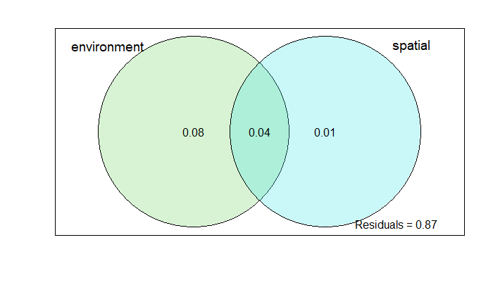

```r
plot(vp1, bg = c(3, 5), Xnames = c("environment", "spatial"))
```

```r
vp2 <- varpart(pol.pca.hell$tab, Sites[,7:11], sel.lw.pol$best$MEM.select)
vp2
```

```
Partition of variance in RDA

Call: varpart(Y = pol.pca.hell$tab, X = Sites[, 7:11], sel.lw.pol$best$MEM.select)

Explanatory tables:
X1:  Sites[, 7:11]
X2:  sel.lw.pol$best$MEM.select

No. of explanatory tables: 2
Total variation (SS): 209.24
            Variance: 10.462
No. of observations: 21

Partition table:
```

|  | Df | R.squared | Adj.R.squared | Testable |
| --- | --- | --- | --- | --- |
| [a+b] = X1 | 10 | 0.54638 | 0.09276 | TRUE |
| [b+c] = X2 | 2 | 0.15848 | 0.06498 | TRUE |
| [a+b+c] = X1+X2 | 12 | 0.65773 | 0.14432 | TRUE |
| Individual fractions |  |  |  |  |
| [a] = X1\|X2 | 10 |  | 0.07934 | TRUE |
| [b] | 0 |  | 0.01342 | FALSE |
| [c] = X2\|X1 | 2 |  | 0.05156 | TRUE |
| [d] = Residuals |  |  | 0.85568 | FALSE |

```
---
Use function ‘rda’ to test significance of fractions of interest
```

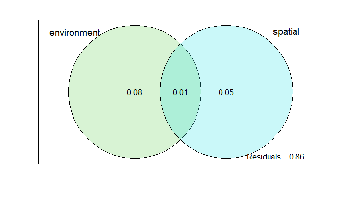

```r
plot(vp2, bg = c(3, 5), Xnames = c("environment", "spatial"))
```

### Now for the interaction network

making unique interactions dataset

```r
unique_interations <- unique(c(plyr::aaply(igraph::get.edgelist(networks[[1]]), 1, function(x) stringr::str_c(x,
                                                                              collapse = "--")),
plyr::aaply(igraph::get.edgelist(networks[[2]]), 1, function(x) stringr::str_c(x,
                                                                              collapse = "--")),
plyr::aaply(igraph::get.edgelist(networks[[3]]), 1, function(x) stringr::str_c(x,
                                                                              collapse = "--")),
plyr::aaply(igraph::get.edgelist(networks[[4]]), 1, function(x) stringr::str_c(x,
                                                                              collapse = "--")),
plyr::aaply(igraph::get.edgelist(networks[[5]]), 1, function(x) stringr::str_c(x,
                                                                              collapse = "--")),
plyr::aaply(igraph::get.edgelist(networks[[6]]), 1, function(x) stringr::str_c(x,
                                                                              collapse = "--")),
plyr::aaply(igraph::get.edgelist(networks[[7]]), 1, function(x) stringr::str_c(x,
                                                                              collapse = "--")),
plyr::aaply(igraph::get.edgelist(networks[[8]]), 1, function(x) stringr::str_c(x,
                                                                              collapse = "--")),
plyr::aaply(igraph::get.edgelist(networks[[9]]), 1, function(x) stringr::str_c(x,
                                                                              collapse = "--")),
plyr::aaply(igraph::get.edgelist(networks[[10]]), 1, function(x) stringr::str_c(x,
                                                                              collapse = "--")),
plyr::aaply(igraph::get.edgelist(networks[[11]]), 1, function(x) stringr::str_c(x,
                                                                              collapse = "--")),
plyr::aaply(igraph::get.edgelist(networks[[12]]), 1, function(x) stringr::str_c(x,
                                                                              collapse = "--")),
plyr::aaply(igraph::get.edgelist(networks[[13]]), 1, function(x) stringr::str_c(x,
                                                                              collapse = "--")),
plyr::aaply(igraph::get.edgelist(networks[[14]]), 1, function(x) stringr::str_c(x,
                                                                              collapse = "--")),
plyr::aaply(igraph::get.edgelist(networks[[15]]), 1, function(x) stringr::str_c(x,
                                                                              collapse = "--")),
plyr::aaply(igraph::get.edgelist(networks[[16]]), 1, function(x) stringr::str_c(x,
                                                                              collapse = "--")),
plyr::aaply(igraph::get.edgelist(networks[[17]]), 1, function(x) stringr::str_c(x,
                                                                              collapse = "--")),
plyr::aaply(igraph::get.edgelist(networks[[18]]), 1, function(x) stringr::str_c(x,
                                                                              collapse = "--")),
plyr::aaply(igraph::get.edgelist(networks[[19]]), 1, function(x) stringr::str_c(x,
                                                                              collapse = "--")),
plyr::aaply(igraph::get.edgelist(networks[[20]]), 1, function(x) stringr::str_c(x,
                                                                              collapse = "--")),
plyr::aaply(igraph::get.edgelist(networks[[21]]), 1, function(x) stringr::str_c(x,
                                                                              collapse = "--"))))

Network_Matrix <- matrix(data = NA, nrow = 21, ncol = 854)
colnames(Network_Matrix) <- unique_interations




bg = igraph::graph.incidence(netlist[[1]], weighted =TRUE)


interaction_weights_list <- list()

for(i in seq_along(1:21)){
interaction_weights_list[[i]] <- as.data.frame(cbind(igraph::edge_attr(igraph::graph.incidence(netlist[[i]], weighted =TRUE))$weight, plyr::aaply(igraph::get.edgelist(networks[[i]]), 1, function(x) stringr::str_c(x,  collapse = "--"))))
}


interaction_weights_list[[1]]$V2 ==
length(as.numeric(interaction_weights_list[[1]]$V1))
```

```
 [1] FALSE FALSE FALSE FALSE FALSE FALSE FALSE FALSE FALSE FALSE FALSE FALSE FALSE FALSE FALSE FALSE FALSE FALSE FALSE FALSE
[21] FALSE FALSE FALSE FALSE FALSE FALSE FALSE FALSE FALSE FALSE FALSE FALSE FALSE FALSE FALSE FALSE FALSE FALSE FALSE FALSE
[41] FALSE FALSE FALSE FALSE FALSE FALSE FALSE FALSE FALSE FALSE FALSE FALSE FALSE FALSE FALSE FALSE FALSE FALSE FALSE FALSE
[61] FALSE FALSE FALSE FALSE FALSE FALSE FALSE FALSE FALSE FALSE FALSE FALSE FALSE FALSE FALSE FALSE FALSE FALSE
```

```r
i=1
e=1
f=1

for(i in seq_along(1:21)){
  for(e in seq_along(1:854)){
    for(f in seq_along(1:length(as.numeric(interaction_weights_list[[i]]$V1)))){

    if(colnames(Network_Matrix)[e] == interaction_weights_list[[i]]$V2[f])
    Network_Matrix[i,e] <- interaction_weights_list[[i]]$V1[f]
    else(next)
    }
  }
}

Network_Matrix <- as.data.frame(Network_Matrix)
Network_Matrix[is.na(Network_Matrix)] <- 0

for(e in seq_along(1:854)){
Network_Matrix[,e] <- as.numeric(Network_Matrix[,e])
}
```

### MULTISPATI analysis

When multivariate data are considered, it is possible to search for spatial structures by computing univariate statistics (e.g., Moran’s Coefficient) on each variable separately. Another alternative is to summarize data by multivariate methods and then detect spatial structures using the output of the analysis. For instance, we applied a centred principal component analysis on the abundance data:

```r
Network_Matrix_hell <- decostand(Network_Matrix, "hellinger")

pca.hell.net <- dudi.pca(Network_Matrix_hell, scale = FALSE, scannf = FALSE, nf = 2)
```

### Selection of SWM and MEM

```r
cand.lw <- listw.candidates(Coord, nb = c("gab", "rel", "pcnm", "dnear"), weights = c("bin", "flin"))
```

```
zero sum general weights
```

The function `listw.select` proposes different methods for selecting a SWM (Bauman, Drouet, Fortin, et al. 2018). The procedure is very similar to the one proposed by `mem.select` except that p-value corrections are applied on global tests taking into account the fact that several candidates are used. By default `(method = "FWD")`, it applies forward selection on the significant SWMs and selects among these the SWM for which the subset of MEMs yields the highest adjusted R.

```r
sel.lw.net <- listw.select(pca.hell.net$tab, candidates = cand.lw, nperm = 99)
```

```
Procedure stopped (adjR2thresh criteria) adjR2cum = 0.088036 with 4 variables (> 0.087365)
Procedure stopped (alpha criteria): pvalue for variable 4 is 0.240000 (> 0.050000)
```

A summary of the procedure is available:

```r
sel.lw.net$candidates
```

|  | R2Adj | Pvalue | N.var | R2Adj.select |
| --- | --- | --- | --- | --- |
| DBEM_PCNM | 0.05161890 | 0.29494584 | NA | NA |
| Gabriel_Binary | 0.08736463 | 0.03107793 | 3 | 0.07932378 |
| Gabriel_Linear | 0.08973773 | 0.05333884 | NA | NA |
| Relative_Binary | 0.10470072 | 0.01391628 | 3 | 0.07024053 |
| Relative_Linear | 0.08051032 | 0.10422026 | NA | NA |
| Dnear10.19_Binary | 0.05116154 | 0.28081831 | NA | NA |
| Dnear10.19_Linear | 0.07469398 | 0.09783099 | NA | NA |

```r
sel.lw.net$best.id
```

```
Gabriel_Binary
             2
```

The corresponding SWM can be obtained by

```r
lw.best.net <- cand.lw[[sel.lw.net$best.id]]
#The subset of MEMs corresponding to the best SWM is also returned by the function:

sel.lw.net$best
```

```
$global.test
$global.test$obs
[1] 0.08736463

$global.test$pvalue
[1] 0.03107793


$MEM.select
Orthobasis with 21 rows and 3 columns
Only 6 rows and 3 columns are shown
       MEM1       MEM4         MEM5
1 -1.506701  0.8647428 -0.543394452
2 -1.975227  0.1926926  0.002171172
3 -1.109440 -1.7188001  1.466614337
4 -1.035003  1.0132375 -0.618462291
5 -0.291134 -1.7727219  0.967561803
6 -1.393024  1.3441670 -0.882655739

$summary
```

|  | variables | order | R2 | R2Cum | AdjR2Cum | pvalue |
| --- | --- | --- | --- | --- | --- | --- |
| 1 | MEM1 | 1 | 0.08689496 | 0.08689496 | 0.03883680 | 0.01 |
| 2 | MEM4 | 4 | 0.06965472 | 0.15654968 | 0.06283298 | 0.01 |
| 3 | MEM5 | 5 | 0.06087553 | 0.21742521 | 0.07932378 | 0.05 |

```
NA
```

### Variation partitioning

Spatial structures identified by Redundancy Analysis in the previous section can be due to niche filtering or other processes (e.g., neutral dynamics). Variation partitioning (Borcard, Legendre, and Drapeau 1992) based on adjusted R2 (Peres-Neto et al. 2006) can be used to identify the part of spatial structures that can be explained or not by environmental predictors. This method is implemented in the function varpart of package vegan that is able to deal with up to four tables of predictors:

```r
library(vegan)

vp3 <- varpart(pca.hell.net$tab, Sites[,7:11], sel.lw.net$best$MEM.select)
vp3
```

```
Partition of variance in RDA

Call: varpart(Y = pca.hell.net$tab, X = Sites[, 7:11], sel.lw.net$best$MEM.select)

Explanatory tables:
X1:  Sites[, 7:11]
X2:  sel.lw.net$best$MEM.select

No. of explanatory tables: 2
Total variation (SS): 15.695
            Variance: 0.78475
No. of observations: 21

Partition table:
```

|  | Df | R.squared | Adj.R.squared | Testable |
| --- | --- | --- | --- | --- |
| [a+b] = X1 | 10 | 0.55449 | 0.10898 | TRUE |
| [b+c] = X2 | 3 | 0.21743 | 0.07932 | TRUE |
| [a+b+c] = X1+X2 | 13 | 0.71281 | 0.17946 | TRUE |
| Individual fractions |  |  |  |  |
| [a] = X1\|X2 | 10 |  | 0.10013 | TRUE |
| [b] | 0 |  | 0.00885 | FALSE |
| [c] = X2\|X1 | 3 |  | 0.07048 | TRUE |
| [d] = Residuals |  |  | 0.82054 | FALSE |

```
---
Use function ‘rda’ to test significance of fractions of interest
```

```r
vp5 <- varpart(pca.hell.net$tab, Sites[,7:11], pla.pca.hell$l1, sel.lw.net$best$MEM.select)
vp5
```

```
Partition of variance in RDA

Call: varpart(Y = pca.hell.net$tab, X = Sites[, 7:11], pla.pca.hell$l1, sel.lw.net$best$MEM.select)

Explanatory tables:
X1:  Sites[, 7:11]
X2:  pla.pca.hell$l1
X3:  sel.lw.net$best$MEM.select

No. of explanatory tables: 3
Total variation (SS): 15.695
            Variance: 0.78475
No. of observations: 21

Partition table:
```

|  | Df | R.square | Adj.R.square | Testable |
| --- | --- | --- | --- | --- |
| [a+d+f+g] = X1 | 10 | 0.55449 | 0.10898 | TRUE |
| [b+d+e+g] = X2 | 2 | 0.18241 | 0.09157 | TRUE |
| [c+e+f+g] = X3 | 3 | 0.21743 | 0.07932 | TRUE |
| [a+b+d+e+f+g] = X1+X2 | 12 | 0.65707 | 0.14269 | TRUE |
| [a+c+d+e+f+g] = X1+X3 | 13 | 0.71281 | 0.17946 | TRUE |
| [b+c+d+e+f+g] = X2+X3 | 5 | 0.34670 | 0.12894 | TRUE |
| [a+b+c+d+e+f+g] = All | 15 | 0.80079 | 0.20316 | TRUE |
| Individual fractions |  |  |  |  |
| [a] = X1 \| X2+X3 | 10 |  | 0.07423 | TRUE |
| [b] = X2 \| X1+X3 | 2 |  | 0.02370 | TRUE |

[output cut: 13 more lines]

```
---
Use function ‘rda’ to test significance of fractions of interest
```

```r
vp6 <- varpart(pca.hell.net$tab, Sites[,7:11], pol.pca.hell$l1, sel.lw.net$best$MEM.select)
vp6
```

```
Partition of variance in RDA

Call: varpart(Y = pca.hell.net$tab, X = Sites[, 7:11], pol.pca.hell$l1, sel.lw.net$best$MEM.select)

Explanatory tables:
X1:  Sites[, 7:11]
X2:  pol.pca.hell$l1
X3:  sel.lw.net$best$MEM.select

No. of explanatory tables: 3
Total variation (SS): 15.695
            Variance: 0.78475
No. of observations: 21

Partition table:
```

|  | Df | R.square | Adj.R.square | Testable |
| --- | --- | --- | --- | --- |
| [a+d+f+g] = X1 | 10 | 0.55449 | 0.10898 | TRUE |
| [b+d+e+g] = X2 | 2 | 0.15176 | 0.05751 | TRUE |
| [c+e+f+g] = X3 | 3 | 0.21743 | 0.07932 | TRUE |
| [a+b+d+e+f+g] = X1+X2 | 12 | 0.64159 | 0.10398 | TRUE |
| [a+c+d+e+f+g] = X1+X3 | 13 | 0.71281 | 0.17946 | TRUE |
| [b+c+d+e+f+g] = X2+X3 | 5 | 0.32165 | 0.09553 | TRUE |
| [a+b+c+d+e+f+g] = All | 15 | 0.79650 | 0.18601 | TRUE |
| Individual fractions |  |  |  |  |
| [a] = X1 \| X2+X3 | 10 |  | 0.09047 | TRUE |
| [b] = X2 \| X1+X3 | 2 |  | 0.00655 | TRUE |

[output cut: 13 more lines]

```
---
Use function ‘rda’ to test significance of fractions of interest
```

```r
vp4 <- varpart(pca.hell.net$tab, Sites[,7:11], pla.pca.hell$l1, pol.pca.hell$l1, sel.lw.net$best$MEM.select)
vp4
```

```
Partition of variance in RDA

Call: varpart(Y = pca.hell.net$tab, X = Sites[, 7:11], pla.pca.hell$l1, pol.pca.hell$l1,
sel.lw.net$best$MEM.select)

Explanatory tables:
X1:  Sites[, 7:11]
X2:  pla.pca.hell$l1
X3:  pol.pca.hell$l1
X4:  sel.lw.net$best$MEM.select

No. of explanatory tables: 4
Total variation (SS): 15.695
            Variance: 0.78475
No. of observations: 21

Partition table:
```

|  | Df | R.square | Adj.R.square | Testable |
| --- | --- | --- | --- | --- |
| [aeghklno] = X1 | 10 | 0.55449 | 0.10898 | TRUE |
| [befiklmo] = X2 | 2 | 0.18241 | 0.09157 | TRUE |
| [cfgjlmno] = X3 | 2 | 0.15176 | 0.05751 | TRUE |
| [dhijkmno] = X4 | 3 | 0.21743 | 0.07932 | TRUE |
| [abefghiklmno] = X1+X2 | 12 | 0.65707 | 0.14269 | TRUE |
| [acefghjklmno] = X1+X3 | 12 | 0.64159 | 0.10398 | TRUE |
| [adeghijklmno] = X1+X4 | 13 | 0.71281 | 0.17946 | TRUE |
| [bcefgijklmno] = X2+X3 | 4 | 0.28056 | 0.10070 | TRUE |
| [bdefhijklmno] = X2+X4 | 5 | 0.34670 | 0.12894 | TRUE |
| [cdfghijklmno] = X3+X4 | 5 | 0.32165 | 0.09553 | TRUE |

[output cut: 48 more lines]

```
---
Use function ‘rda’ to test significance of fractions of interest
```

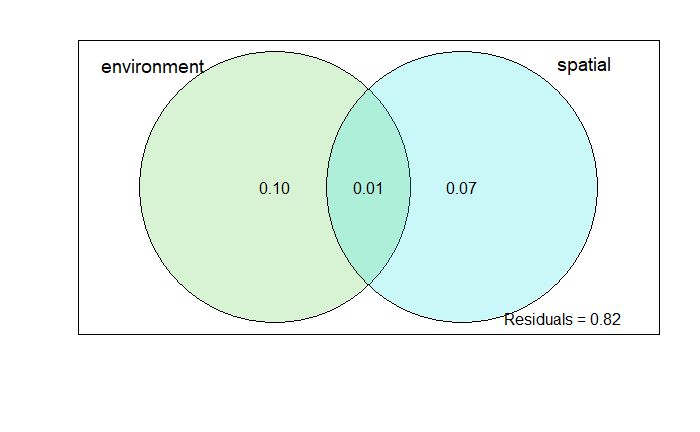

```r
plot(vp3, bg = c(3, 5), Xnames = c("environment", "spatial"))
```

[figure not shown]

```r
plot(vp4, bg = c(3, 5, 7, 1), Xnames = c("environment", "spatial", "plant b", "pol b"))
```

[figure not shown]

```r
plot(vp5, bg = c(3, 5, 7), Xnames = c("environment", "spatial", "plant b"))
```

[figure not shown]

```r
plot(vp6, bg = c(3, 5, 1), Xnames = c("environment", "spatial", "pol b"))
```